# DS4IR

Processamento de Dados

Professor Davi Moreira

Professor Rafael Magalhães

16-07-2020

## Motivação

- Uma organização internacional (OI) tem o interesse de desenvolver projetos de promoção de direitos humanos em diferentes regiões do globo.
- Sua grande preocupação é cuidar para que desde o início a formulação dos projetos considere caracteríticas regionais relacionadas à religião e o regime político estabelecido.

## Banco de dados: Quality of Government

Vamos utilizar o [Quality of Government](https://qog.pol.gu.se/) para selecionar algumas características importantes dos sistemas políticos de diferentes países.

Trata-se de um projeto que organiza diferentes bases de dados relacionados a Política Comparada e Relações Internacionais, facilitando análises de n grande. Vale a pena olhar o livro de códigos!

> “Happy families are all alike; every unhappy family is unhappy in its own way.”

> — Liev Tolstoi

> “Tidy datasets are all alike; every messy dataset is messy in its own way.”

> — Hadley Wickham

## Tidy Data vs. Messy Data

- No mundo real, a grande maioria dos dados não vai estar no formato que desejamos. Nessa aula vamos aprender a processar os dados para que eles fiquem *tidy* de acordo com nossos objetivos.

## *Tidyverse*

Todas as ferramentas que vamos ver fazem parte do [tidyverse](https://www.tidyverse.org/), um conjunto de pacotes para tratamento de bases de dados.

```r
# install.packages("tidyverse")
library(tidyverse)
```

Esse conjunto de pacotes segue um conjunto de princípios que estão se tornando o padrão de análise de dados no `R`.

[figure not shown]

[The tidy tools manifesto](https://cran.r-project.org/web/packages/tidyverse/vignettes/manifesto.html)

[figure not shown]

O *pipe* (`%>%`) deixa a ordem das operações mais clara, tornando o código mais fácil de ler e de compreender.

```r
# Um vetor qualquer
x <- c(1:10)

# Um cálculo simples com código complicado
sum(sqrt(factorial(x)))

# O mesmo cálculo com %>%
x %>% factorial() %>% sqrt() %>% sum()
```

## Exercício

- Utilizando o operador `%>%` e as funções `sqrt()` e `plot()` obtenha uma visualização da raiz quadrada de cada um dos elementos do vetor abaixo:

```r
# Vetor
x <- seq(0, 10, .1)
```

## Exercício: resposta

- Utilizando o operador `%>%` e as funções `sqrt()` e `plot()` obtenha uma visualização da raiz quadrada de cada um dos elementos do vetor abaixo:

```r
# Vetor
x <- seq(0, 10, .1)

# resposta
x %>% sqrt() %>% plot()
```

## Carregando dados

- É recomendável adotar a estrutura de projetos em sua análise de dados ([Workflow: projects](https://r4ds.had.co.nz/workflow-projects.html)).
- Otimiza a colaboração e o compartilhamento de sua análise ao sempre usar a estrutura do projeto como referência de seus arquivos.
- Como toda análise de dados pressupõe a existência dos mesmos, o `RStudio` usa o diretório do projeto como raiz e pode-se navegar facilmente por suas pastas. Para ajudar nessa tarefa, usamos o pacote `here`.

## Carregando dados: exemplo prático

- Vamos carregar a principal base de dados dessa aula usando a função `read_csv` e alocá-la num objeto chamado `qog`:

```r
library(here)

# importando base de dados
qog <- read_csv(here("data", "qog_bas_ts_jan20.csv"))
```

## Carregando dados: outras possibilidades

Praticamente todo tipo de estrutura de dados pode ser importada para análise no `R`. Os seguintes pacotes `tidyverse` são recomendados:

- `haven`: para formatos SPSS, Stata, e SAS.
- `readxl`: para arquivos do Microsoft Excel (.xls e .xlsx).
- `DBI`: para RMySQL, RSQLite, RPostgreSQL, etc.
- `jsonlite`: para json.
- `xml2` para XML.

## Verbos

No `tidyverse` vamos tratar de **verbos** (funções) que descrevem passo-a-passo as tarefas de processamento necessárias:

- Selecionar casos com `filter()`
- Ordenar variáveis com `arrange()`
- Processar colunas com `select()` e `rename()`
- Criar variáveis com `mutate()`
- Recodificar variáveis com `case_when()`
- Resumir informações com `summarise()` e `group_by()`
- Reorganizar bases com `pivot_wider()` e `pivot_longer()`
- Mesclar bases com `left_join()`
- Combinar diferentes passos de processamento
- Aplicação

## Selecionar colunas com `select()`

Em uma bases de dados com um número muito grande de colunas, você pode querer selecionar apenas aquelas que são mais importantes para uma determinada tarefa.

```r
# Selecionar apenas variáveis de democracia
qog %>%
  select(cname, chga_demo, p_polity2)

# Selecionar todas as colunas menos duas
qog %>%
  select(-(3:4))
```

## Selecionar colunas com `select()`

```r
# Algumas funções mais específicas
banco_mundial <- qog %>%
  select(starts_with("wb"))

welfare <- qog %>%
  select(ends_with("_wel"))

# Alterar a ordem de apresentação das variáveis
qog <- qog %>%
  select(chga_demo, p_polity2, everything())
```

## Renomear variáveis com `rename()`

A função `rename()` é prima da `select()`. Com ela, conseguimos trocar o nome de uma variável (`select()` também faz isso, mas apaga todas as outras variáveis do banco)

```r
# IMPORTANTE: o novo nome da variável vem primeiro
qog %>%
  rename(democracia = chga_demo) %>%
  select(cname, democracia)
```

## Criar variáveis com `mutate()`

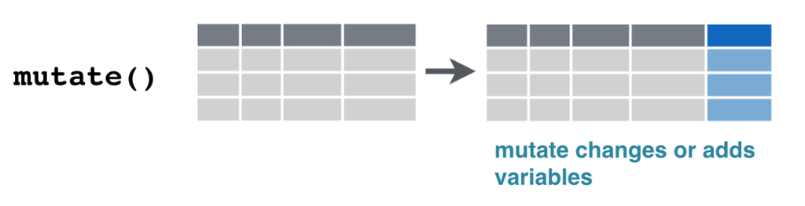

Esse é um dos comandos mais úteis de todo pacote. Frequentemente, as bases de dados não têm todas as informações que queremos, mas podemos criar nossas próprias variáveis a partir das já existentes.

```r
# Note que as variáveis ccode e year continuam no banco de dados
qog %>%
  mutate(ID = paste0(ccode, "/", year)) %>%
  select(cname, ID)

# O comando transmute faz a mesma coisa, mas só mantém a variável nova
qog %>%
  transmute(ID = paste0(ccode, "/", year))
```

## Recodificar variáveis com `case_when()`

Uma das funções mais úteis para ser usada com o `mutate()` é o `case_when()`. Com ela, podemos recodificar nossas variáveis para criar faixas de idade, salário, sexo, etc.

**Importante**: sempre opere do caso específico para o geral.

```r
# Criar variável dummy para reclassificação do Polity IV
qog %>%
  mutate(pol_bin = case_when(p_polity2 >= 7 ~ "Democracia",
                             TRUE ~ "Autocracia")) %>%
  select(cname, pol_bin, p_polity2)

# Podemos ter mais de duas condições
qog %>%
  mutate(pol_cat = case_when(p_polity2 > 7 ~ "Muito Democrático",
                             p_polity2 > 5 & p_polity2 <= 7 ~ "Democrático",
                                   TRUE ~ "Autocracia")) %>%
    select(cname, pol_cat, p_polity2) %>% arrange(desc(p_polity2))
```

## Selecionar casos com `filter()`

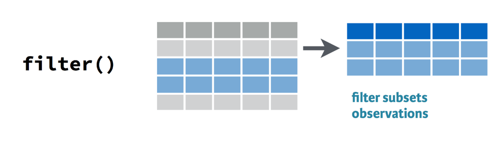

O comando `filter()` **seleciona observações**, como o filtro do Excel.

```r
qog %>%
  filter(year == 2015)
```

## Relembrando os operadores lógicos

Podemos usar operadores lógicos para aplicar filtros com múltiplos critérios, assim como armazenar os resultados em um novo objeto.

```r
qog %>%
  filter(year == 2000 & chga_demo == 1) %>%
  select(cname, year, chga_demo)
```

## Ordenar variáveis com `arrange()`

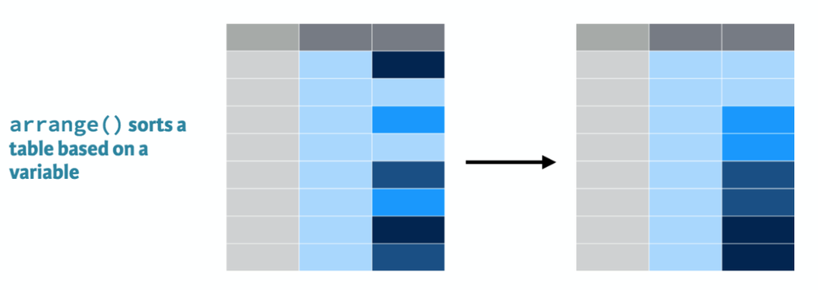

O comando `arrange()` ordena o banco de dados com base na variável que você selecionar. Variáveis adicionais serão usadas como critério de desempate

```r
# Ordenamento padrão é ascendente
qog %>%
  arrange(chga_demo, p_polity2) %>%
  select(cname, year, p_polity2)

# Ordenamento descendente
qog %>%
  arrange(desc(p_polity2)) %>%
  select(cname, year, p_polity2)
```

## Resumir informações com `summarise()` e `group_by()`

O comando `summarise()` resume os dados. O `summarise()` fica mais interessante quando utilizado em conjunto com o `group_by()`, que permite agrupar as observações de acordo com categorias de uma variável que você escolher, criando subtotais.

```r
qog %>%
  group_by(year, ht_region) %>%
  summarise(cristao = mean(arda_chgenpct),
            islamico = mean(arda_isgenpct),
            judeu = mean(arda_jdgenpct)) %>% drop_na()
```

Além da função `mean()` utilizada acima, outras funções úteis são `sum()`, `median()`, `sd()`, `n()` e `n_distinct()`.

## Outras funções para agrupar

A função `group_by` pode ser combinada com outras funções que vimos acima para separar operações por grupo:

**Importante**: Depois de fazer a operação agrupada, voltamos à forma inicial da base com o comando `ungroup()`. Se não fizermos isso, todas as próximas operações nesse objeto serão aplicadas por grupo.

```r
qog_group <- qog %>%
  group_by(year, ht_region, p_polity2) %>%
  summarise(cristao = mean(arda_chgenpct),
            islamico = mean(arda_isgenpct),
            judeu = mean(arda_jdgenpct)) %>%
  arrange(p_polity2) %>%
  ungroup()

qog_group
```

## Exercício

Crie o objeto `qog_group` que seja o resultado do cálculo da mediana `median()` da preponderância das religiões cristã, islâmica e judaica por região (`ht_region`) no ano (`year`) de 2000:

## Exercício: resposta

Crie o objeto `qog_group` que seja o resultado do cálculo da mediana `median()` da preponderância das religiões cristã, islâmica e judaica por região (`ht_region`) no ano (`year`) de 2000:

```r
qog_group <- qog %>% filter(year == 2000) %>%
  group_by(ht_region) %>%
  summarise(cristao = median(arda_chgenpct),
            islamico = median(arda_isgenpct),
            judeu = median(arda_jdgenpct)) %>%
  ungroup() %>% drop_na()

qog_group
```

## Reorganizar bases com `pivot_wider()` e `pivot_longer()`

A melhor maneira de entender a utilidade das funções `pivot_wider()` e `pivot_longer()` é por meio de um exemplo.

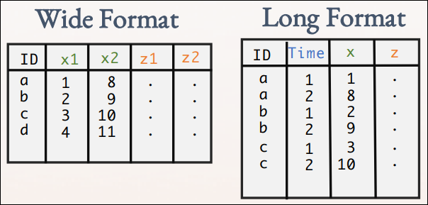

Nossa base de dados está em um formato **long**, ou seja: cada país/ano está em uma linha, e seus atributos estão em colunas. Você pode ter notado que este é, também, o formato *tidy*.

**Nota**: É muito mais comum precisar fazer a transformação **wide** –> **long** do que o contrário!

## `privot_wider()`: transforma dados *long* em *wide*

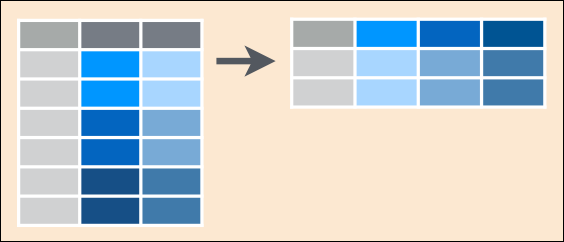

Vamos produzir uma matriz com países (`cname`) nas linhas, anos (`year`) nas colunas e o valor da variável `p_polity2` em cada elemento.

`p_polity2`: “Revised Combined Polity Score: The polity score is computed by subtracting the p_autoc score from the p_democ score; the resulting unified polity scale ranges from +10 (strongly democratic) to -10 (strongly autocratic).”

## `privot_wider()`: transforma dados *long* em *wide*

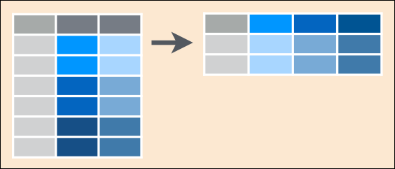

```r
qog_wide <- qog %>% select(cname, year, p_polity2) %>%
    pivot_wider(names_from = year, values_from = p_polity2)

qog_wide
```

## `pivot_longer()`: transforma dados *wide* em *long*

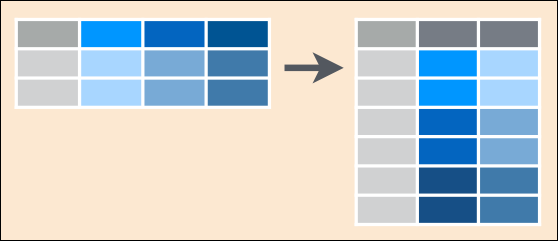

Vamos usar o objeto `qog_wide` que criamos e colocá-lo em seu formato original com a função `pivot_longer()`.

```r
qog_long <- qog_wide %>%
    pivot_longer(-cname, names_to = "year", values_to = "p_polity2")

qog_long
```

## Unindo bases de dados

*“There are two certainties in life: death and bad merges”*

Nem sempre (quase nunca) as informações que queremos vão estar em uma única base de dados. Nesses casos, precisamos *unir* duas ou mais bases, um processo que exige atenção.

Existem diversos comandos para fazer essa operação. Contudo, vamos focar no que o `tidyverse` nos oferece, em especial o `left_join()`. Vamos ver um exemplo:

## Unindo bases de dados

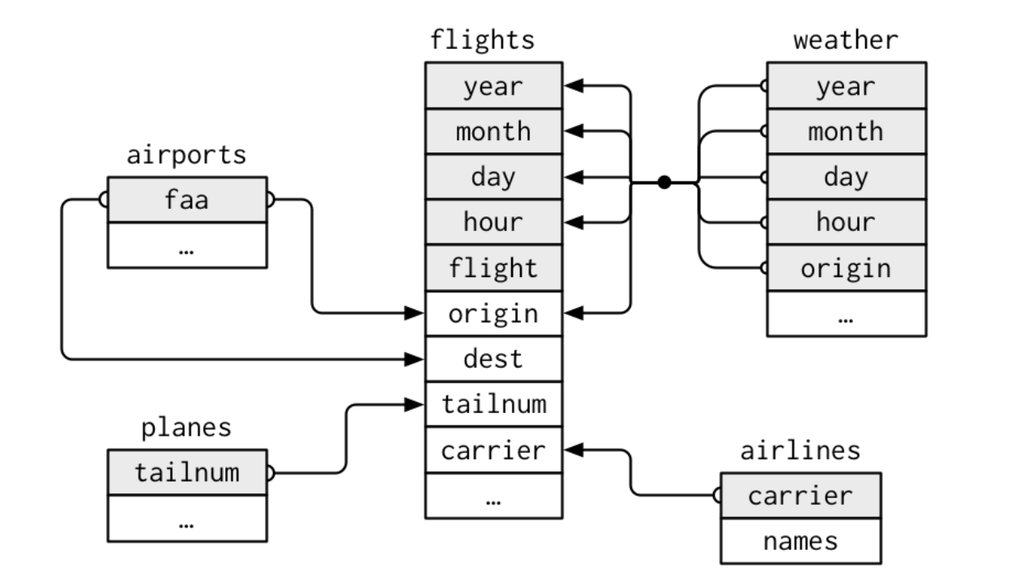

- **flights** se conecta a `planes` por: `tailnum`.
- **flights** se conecta a `airlines` por: `carrier`.
- **flights** se conecta a `airports` por: `origin` e `dest`.
- **flights** se conecta a `weather` por: `origin`, `year`, `month`, `day`, `hour`.

## Comandos para unir bases:

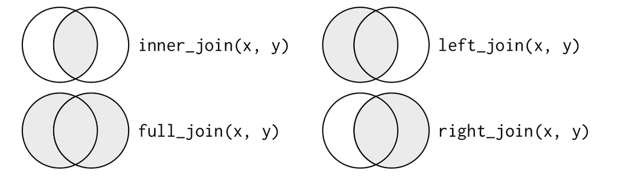

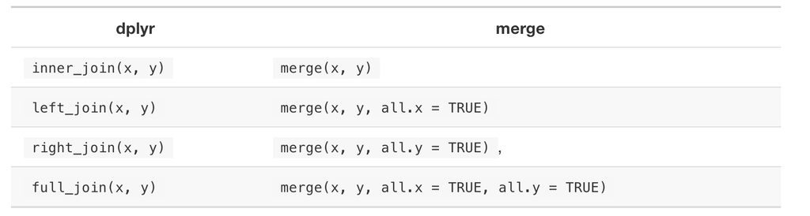

## Comandos para unir bases: `full_join()`

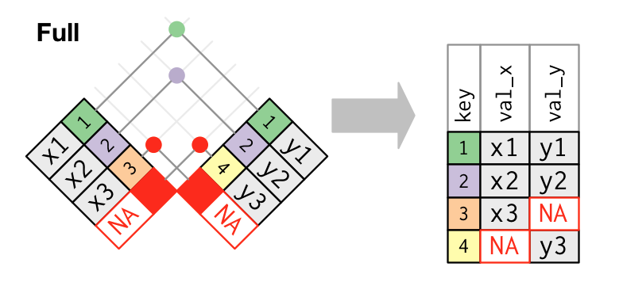

## Comandos para unir bases: `inner_join()`

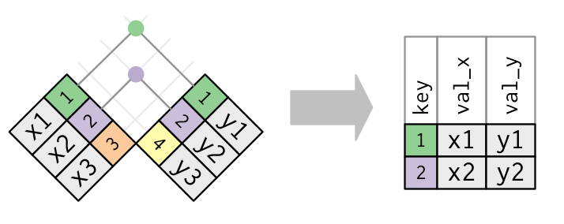

## Comandos para unir bases: `right_join()`

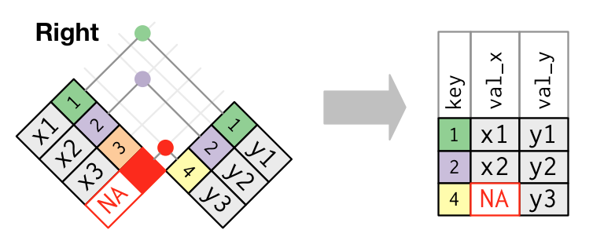

## Comandos para unir bases: `left_join()`

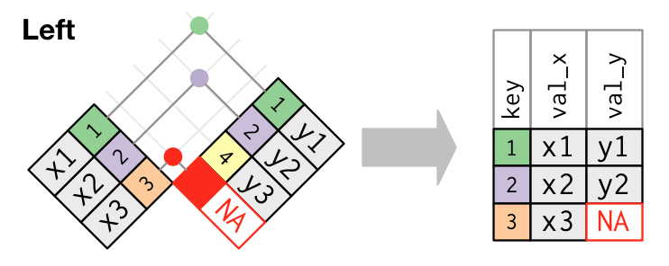

## Material adicional

Alguns materiais interessantes para consulta:

- [Primer: Tidy your Data](https://rstudio.cloud/learn/primers/4)
- [Data Transformation Cheat Sheet](https://github.com/rstudio/cheatsheets/raw/master/data-transformation.pdf)
- [Data Visualization Cheat Sheet](https://github.com/rstudio/cheatsheets/raw/master/data-visualization-2.1.pdf)

## Tarefa da aula

As instruções da tarefa estão no arquivo `NN-class-ds4ir-assignment.rmd` da pasta `assignment` que se encontra na raiz desse projeto.